# Prosper Loan Data

## by Chris Arnell

> Prosper is an online loan company based in San Francisco. They do not have a brick and mortar store like most banks, and this means Prosper has a much lower cost of business than a normal bank. The data supplied contains information for Loans granted between 2009 & 2014

### What is the structure of your dataset?

> The Prosper Loans Data contains 113937 entries for loans given by Prosper after July 2009. Each entry has 81 variables, this seemed rather excessive so using the variable dictionary supplied by Udacity I highlighted variables that were of interest to me...

### What is/are the main feature(s) of interest in your dataset?

> The main features I am going to concentrate my exploration around are:
> - ListingCreationDate, Term, BorrowerAPR, BorrowerRate, EstimatedEffectiveYield, EstimatedLoss, EstimatedReturn, ProsperScore, CreditScoreRangeLower0, CreditScoreRangeUpper, Occupation, StatedMonthlyIncome & LoanOriginalAmount'

### What features in the dataset do you think will help support your investigation into your feature(s) of interest?

> I will focus are the Borrower rate, Eastimated return, Year, Credit Score and also the Prosper Score

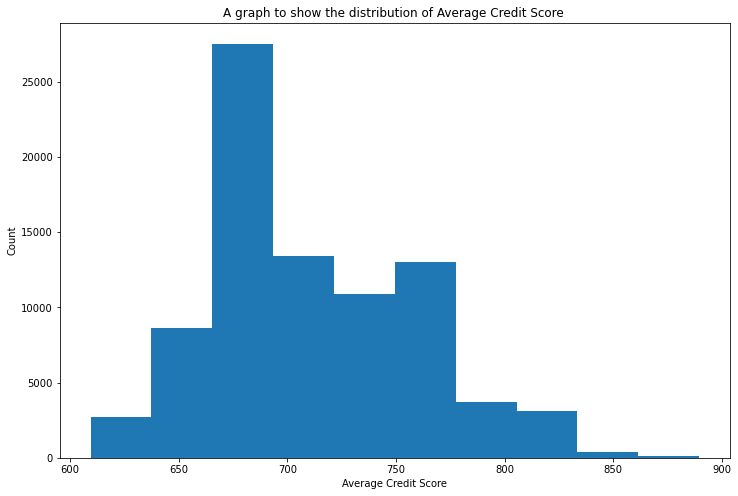

```python
# Distribution of credit score

fig = plt.figure(figsize=(12,8))

# Histogram of of the average scredit score
plt.hist(data = df1, x = 'average_credit_score');

# Titles
plt.title('A graph to show the distribution of Average Credit Score ');
plt.xlabel('Average Credit Score')
plt.ylabel('Count');
```

Plotting a histogram for the Average Credit Score allows me to see the most popular average credit scores were found to be between 675 & 700.

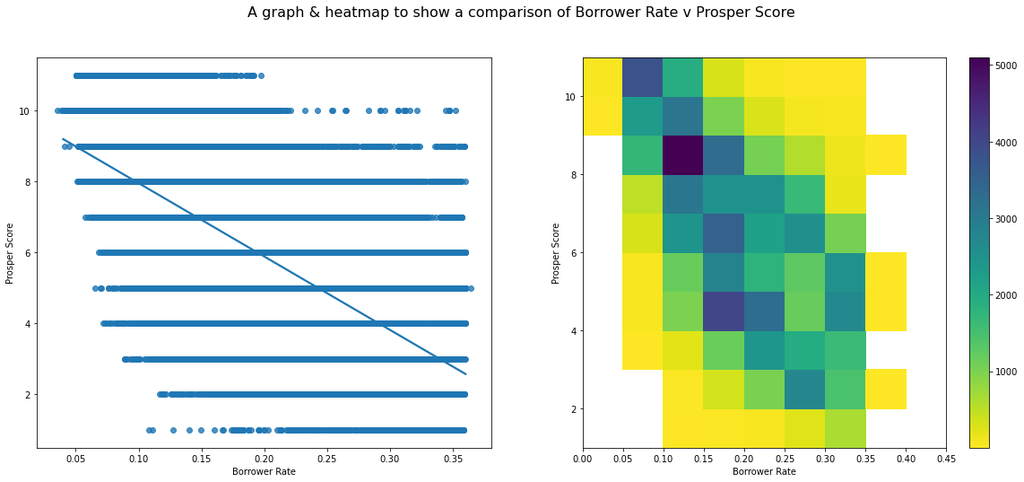

```python
# Borrower Rate v Prosper Score
fig = plt.figure(figsize=(20,8))
fig.suptitle('A graph & heatmap to show a comparison of Borrower Rate v Prosper Score', fontsize = 16)

# Subplot left
plt.subplot(1,2,1)

# Scatter graph with Line of Best Fit for Borrower Rate v Prosper Score
sb.regplot(data = df1, x = 'BorrowerRate', y = 'ProsperScore', x_jitter=0.01);

# Titles
plt.xlabel('Borrower Rate')
plt.ylabel('Prosper Score');

# Bins usesd for heat map
bins_x = np.arange(0, 0.4+0.1, 0.05)
bins_y = np.arange(1, 11+1, 1)

#Subplot right
plt.subplot(1,2,2)

# Heatmap to show concentration of points for Borrower Rate v Prosper Score
plt.hist2d(data = df1, x = 'BorrowerRate', y = 'ProsperScore', cmin=0.25, cmap='viridis_r', bins = [bins_x, bins_y])

# Show colour bar
plt.colorbar()

# Titles

plt.xlabel('Borrower Rate')
plt.ylabel('Prosper Score');
```

From looking at the comparison of Prosper Score v Borrower Rate it shows a clear negative correlation between the 2, as the Prosper Score increases, the Borrower Rate decreases. This makes sense as someone with a higher Proper Score (better) would expect to recieve a lower Borrower Rate.

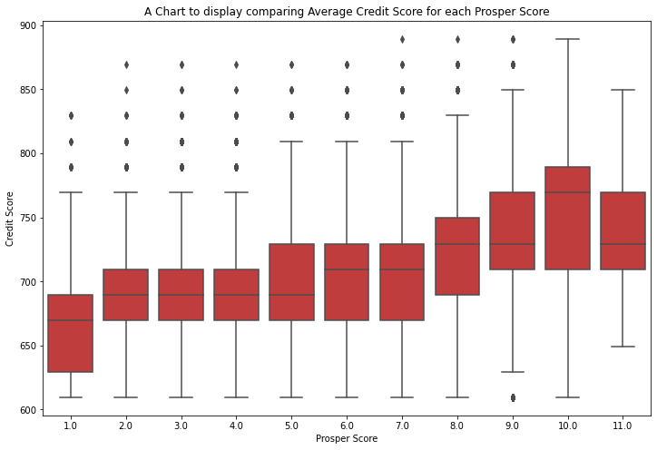

```python
#Credit Score v Prosper Score

fig = plt.figure(figsize=(12,8))

#Boxplot to show Prosper Score v Average Credit Score
sb.boxplot(data = df1, x = 'ProsperScore', y = 'average_credit_score', color = sb.color_palette()[3]);

# Titles
plt.title('A Chart to display comparing Average Credit Score for each Prosper Score')
plt.xlabel('Prosper Score')
plt.ylabel('Credit Score');
```

Plotting all 11 Scores on the X axis can you useful to show alot of information at one. Firstly it is clear to see a positive correlation between Prosper Score & Credit Score, this is to be expected as the two should match pretty closely. Secondly, and more interestingly is how the range, IQ range & Range are almost identical for Prosper Scores of 2,3,& 4. After this these values do follow and upwards trend.

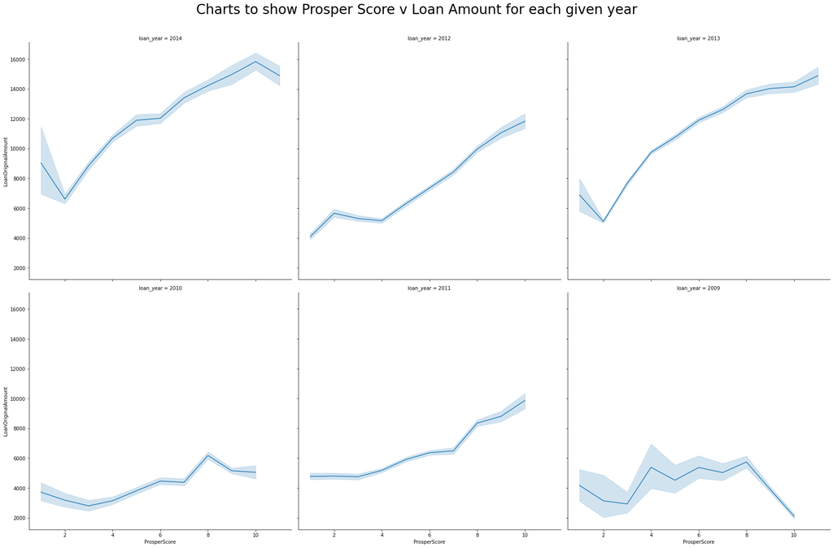

```python
#Prosper Score v LoanOriginalAmount for each Year

# A FacetGrid displaying Prosper Score v Loan Amount for each year
g = sb.FacetGrid(df1, col = "loan_year", height = 8, col_wrap = 3)
g.map(sb.lineplot, 'ProsperScore', 'LoanOriginalAmount');

# Title
g.fig.subplots_adjust(top=0.91) # adjusts placement
g.fig.suptitle('Charts to show Prosper Score v Loan Amount for each given year', fontsize=28); # title text
```

From looking at the grids above displaying Loan Amount v Prosper Score for each year given in the dataset you can see a clear progression from 2009 where Prosper Score showed now relationship with the Loan Amount to 2014 where there is a clear positive correlation between Prosper Score.

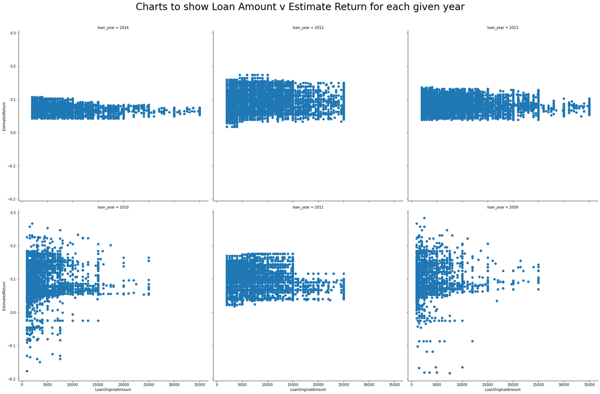

```python
#Loan Amount v Estimated Return for each Year

# FacetGrid to show Loan Amount v Estimated return for each year
g = sb.FacetGrid(df1, col = "loan_year", height = 8, col_wrap = 3)
g.map(plt.scatter, 'LoanOriginalAmount', 'EstimatedReturn');

# Title
g.fig.subplots_adjust(top=0.91) # adjusts placement
g.fig.suptitle('Charts to show Loan Amount v Estimate Return for each given year', fontsize=28); # title text
```

Plotting a grid for Loan Amount v Estimated Returns also shows a natural progression over the years. Looking at the 2009 plot, the plots are extremely varied, some loans offering little return and other having large returns for the same loan amount. Slowly through the years these returns are uniforms so that if we look at the plot for 2014, all loans have estimated returns approximate 0.05 - 0.1.